# Expression of pluripotency genes

John Blischak

**Last updated:** 2015-10-22

**Code version:** 044491cd5df4302bbdcf97ec1313fa184fc31516

```r
library("knitr")
opts_chunk$set(fig.align = "center", fig.width = 10)
```

Treatment of embroyonic stem cells with retinoic acid stimulates them to differentiate into neural precursors. Thus I expect genes involved in maintenance of the pluripotent state to be affected. To investigate this, I downloaded [Table S9](http://journals.plos.org/plosone/article/asset?unique&id=info:doi/10.1371/journal.pone.0056810.s014) of [Dowell et al., 2013](http://journals.plos.org/plosone/article?id=10.1371/journal.pone.0056810) to obtain their list of 354 genes involved in the mouse embryonic stem cell gene regulatory network. They obtained this list from the literature, and used it as a “gold standard” for finding other genes important for pluripotency.

## Setup

Load packages.

```r
library("biomaRt")
library("edgeR")
library("tidyr")
library("ggplot2")
theme_set(theme_bw(base_size = 12))
```

Import the filtered counts matrix.

```r
counts <- read.table("../../data/mouse/counts-matrix-filtered.txt",
                     header = TRUE)
dim(counts)
```

```
## [1] 13738     6
```

```r
head(counts)
```

```
##                    DMSO.REP1 DMSO.REP2 DMSO.REP3 RA.REP1 RA.REP2 RA.REP3
## ENSMUSG00000033845      3312      2890      2922    2981     772    1627
## ENSMUSG00000025903      1837      1789      1459    1348     409     881
## ENSMUSG00000033813       706       675       607     580     132     376
## ENSMUSG00000002459         8        17        15      43      13      48
## ENSMUSG00000033793      1612      1467      1390    1566     417    1081
## ENSMUSG00000025907      1473      1437      1253    1665     556    1167
```

Calculate log cpm.

```r
normalized_lib_sizes <- calcNormFactors(counts)
log_cpm <- cpm(counts, log = TRUE,
                lib.size = colSums(counts) * normalized_lib_sizes)
```

Import the DE results.

```r
de_results <- read.table("../../data/mouse/de-results.txt",
                         header = TRUE)
head(de_results)
```

```
##                          logFC   logCPM       PValue          FDR    de
## ENSMUSG00000033845 -0.13449462 7.535947 3.402753e-01 4.713826e-01 FALSE
## ENSMUSG00000025903 -0.27935785 6.625184 3.944787e-02 8.981354e-02 FALSE
## ENSMUSG00000033813 -0.28073406 5.271903 1.329561e-02 3.736042e-02  TRUE
## ENSMUSG00000002459  1.98438205 1.091352 8.360234e-09 1.242997e-07  TRUE
## ENSMUSG00000033793  0.07886065 6.612570 4.574341e-01 5.857344e-01 FALSE
## ENSMUSG00000025907  0.39736543 6.682437 4.430506e-03 1.520137e-02  TRUE
```

Import the list of pluripotency genes.

```r
pluri <- read.table("../../data/mouse/pluripotency-genes.txt",
                    header = TRUE, stringsAsFactors = FALSE)
head(pluri)
```

```
##     name
## 1 Pou5f1
## 2   Klf2
## 3   Sox2
## 4   Gdf3
## 5   Tcl1
## 6    Fos
```

## Effect of RA treatment on pluripotency genes

Convert to Ensembl gene IDs.

```r
ensembl <- useMart(host = "sep2015.archive.ensembl.org",
                   biomart = "ENSEMBL_MART_ENSEMBL",
                   dataset = "mmusculus_gene_ensembl")
pluri_info <- getBM(attributes = c("ensembl_gene_id", "chromosome_name",
                                  "external_gene_name"),
                      filter = c("external_gene_name", "chromosome_name"),
                      values = list(pluri$name, c(1:19, "MT", "X", "Y")),
                      mart = ensembl)
stopifnot(length(unique(pluri_info$external_gene_name)) == nrow(pluri_info))
head(pluri_info)
```

```
##      ensembl_gene_id chromosome_name external_gene_name
## 1 ENSMUSG00000037035               1              Inhbb
## 2 ENSMUSG00000026288               1             Inpp5d
## 3 ENSMUSG00000019699               1               Akt3
## 4 ENSMUSG00000067336               1              Bmpr2
## 5 ENSMUSG00000060743               1              H3f3a
## 6 ENSMUSG00000041075               1               Fzd7
```

348 of the 354 gene names were successfully converted to Ensembl gene IDs.

Subset the log<sub>2</sub> cpm and create an indicator variable for being a pluripotency gene.

```r
log_cpm_pluri <- log_cpm[rownames(log_cpm) %in% pluri_info$ensembl_gene_id, ]
de_results$pluripotent <- rownames(de_results) %in% pluri_info$ensembl_gene_id
```

299 of the 348 genes with Ensembl annotation are robustly expressed in the current data set.

The heatmap of these pluripotency genes is not very interesting. It separates the treated and untreated just like the full data, and no other clear patterns arise.

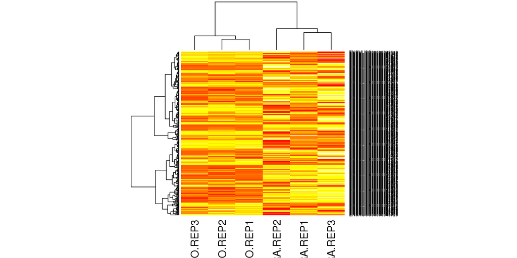

```r
heatmap(log_cpm_pluri)
```

Are pluripotent genes enriched among the differentially expressed genes? I test this using Fisher’s exact test.

```r
pluri_fisher <- fisher.test(x = de_results$pluripotent, y = de_results$de)
pluri_fisher
```

```
##
##  Fisher's Exact Test for Count Data
##
## data:  de_results$pluripotent and de_results$de
## p-value = 0.001108
## alternative hypothesis: true odds ratio is not equal to 1
## 95 percent confidence interval:
##  1.162193 1.865615
## sample estimates:
## odds ratio
##   1.472991
```

Yes, with p-value 0.00. To visualize the enrichment, below are the density plots of the p-values for differential expression for all genes (black line) and the pluripotent genes (red line).

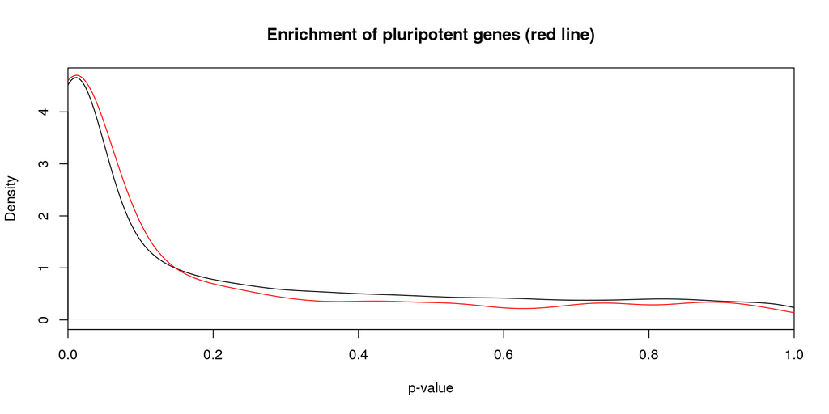

```r
plot(density(de_results$PValue[!de_results$pluripotent]),
     main = "Enrichment of pluripotent genes (red line)",
     xlab = "p-value", xlim = c(0, 1), xaxs = "i")
lines(density(de_results$PValue[de_results$pluripotent]), col = "red")
```

Visualize Oct4 (Pou5f1), Sox2, and Nanog expression.

```r
pluri_ex <- pluri_info[pluri_info$external_gene_name %in% c("Pou5f1", "Sox2", "Nanog"), ]
log_cpm_pluri_ex <- merge(pluri_ex, log_cpm_pluri, by.x = "ensembl_gene_id",
                          by.y = "row.names")
log_cpm_pluri_ex <- gather(log_cpm_pluri_ex, key = "sample", value = "log_cpm",
                           DMSO.REP1:RA.REP3)
log_cpm_pluri_ex <- separate(log_cpm_pluri_ex, col = sample,
                             into = c("treatment", "replicate"), sep = "\\.")
```

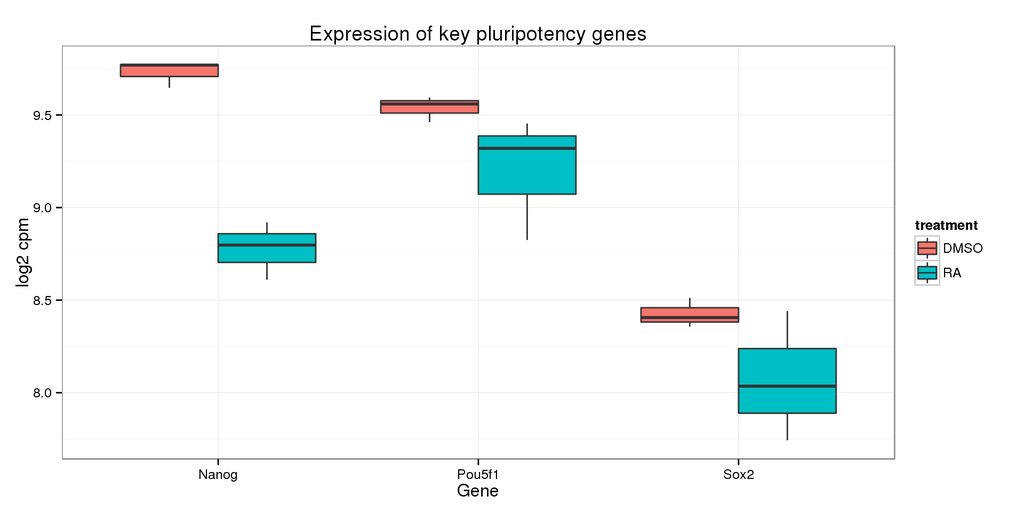

```r
ggplot(log_cpm_pluri_ex, aes(x = external_gene_name, y = log_cpm, fill = treatment)) +
  geom_boxplot() +
  labs(x = "Gene", y = "log2 cpm",
       title = "Expression of key pluripotency genes")
```

After correcting for multiple testing, only Nanog is significantly differentially expressed. However, they are all downregulated with RA treatment.

```r
de_results[pluri_ex$ensembl_gene_id, ]
```

```
##                         logFC   logCPM       PValue          FDR    de
## ENSMUSG00000024406 -0.3134436 9.390958 4.019375e-02 9.116423e-02 FALSE
## ENSMUSG00000074637 -0.3289526 8.273618 4.201403e-02 9.423491e-02 FALSE
## ENSMUSG00000012396 -0.9493025 9.333547 2.198992e-15 6.553090e-14  TRUE
##                    pluripotent
## ENSMUSG00000024406        TRUE
## ENSMUSG00000074637        TRUE
## ENSMUSG00000012396        TRUE
```